# ECO 636: MLR lecture script

# Multinomial Logistic Regression

## Introduction

Multinomial and ordinal logistic regression are an extension of the binomial logistic regression we have been practicing. These additional GLMs allow us to predict to probability of belonging to one of 3 or more groups (rather than just the two of a binomial logistic regression).

- *Multinomial logistic regression* is used when your response variable is categorical with 3 or more groups and those groups have no order (e.g., green, purple, and orange tags)
- *Ordinal logistic regression* is used when your response variable is categorical with 3 or more groups and those groups have an order (e.g., small, medium, and large wingspan)

Here we will practice using a multinomial logistic regression on the Palmer Penguins data. What you learn here can be extended to an ordinal logistic regression :).

Let’s first set up our code…

```r
require(tidyverse)
require(car)
require(ggplot2)
options(scipen = 999)
```

## Palmer penguin data

@allison_horst

Today we will explore the Palmer penguin data collected at the Palmer station, which is part of the Antarctica Long Term Ecological Research (LTER) site. These data include the physical measurements of 344 penguins. The observations also recorded location of measurement (3 different islands), and species of penguin (3 unique species) (see below for more information). These data were collected and made available by Dr. Kristen Gorman and made pretty by Dr. Allison Horst and colleagues.

Let’s check out the Palmer Penguin data.

```r
library(palmerpenguins)
penguins <- penguins
glimpse(penguins)
```

```
## Rows: 344
## Columns: 8
## $ species           <fct> Adelie, Adelie, Adelie, Adelie, Adelie, Adelie, Adel…
## $ island            <fct> Torgersen, Torgersen, Torgersen, Torgersen, Torgerse…
## $ bill_length_mm    <dbl> 39.1, 39.5, 40.3, NA, 36.7, 39.3, 38.9, 39.2, 34.1, …
## $ bill_depth_mm     <dbl> 18.7, 17.4, 18.0, NA, 19.3, 20.6, 17.8, 19.6, 18.1, …
## $ flipper_length_mm <int> 181, 186, 195, NA, 193, 190, 181, 195, 193, 190, 186…
## $ body_mass_g       <int> 3750, 3800, 3250, NA, 3450, 3650, 3625, 4675, 3475, …
## $ sex               <fct> male, female, female, NA, female, male, female, male…
## $ year              <int> 2007, 2007, 2007, 2007, 2007, 2007, 2007, 2007, 2007…
```

```r
view(penguins)
```

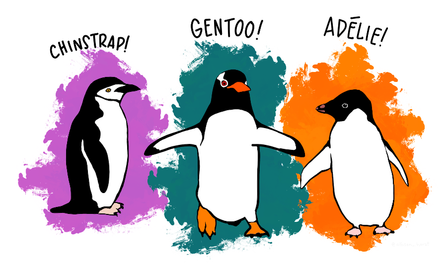

@allison_horst

Neat - here are the definitions of each of the columns:

- Species - a factor denoting penguin species (Adélie, Chinstrap and Gentoo)
- Island - a factor denoting island in Palmer Archipelago, Antarctica (Biscoe, Dream or Torgersen)
- bill_length_mm - a number denoting bill length (millimeters)
- bill_depth_mm - a number denoting bill depth (millimeters)
- flipper_length_mm - an integer denoting flipper length (millimeters)
- body_mass_g - an integer denoting body mass (grams)
- Sex - a factor denoting penguin sex (female, male)

Today we will use a multinomial logistic regression to see if we can predict species by some of the physical measurements!

Let’s go through the modeling process to do so.

## Modeling process

### State the question

Current question: Can the physical characteristics of the penguin be used to predict species of penguin?

Response variable: Species (*categorical variable with 3 groups*)

Explanatory variables: bill_length_mm, bill_depth_mm, flipper_length_mm, body_mass_g (*continuous variables*)

Error distribution: multinomial

Therefore… we are doing a *multinomial logistic regression*!

### Data exploration

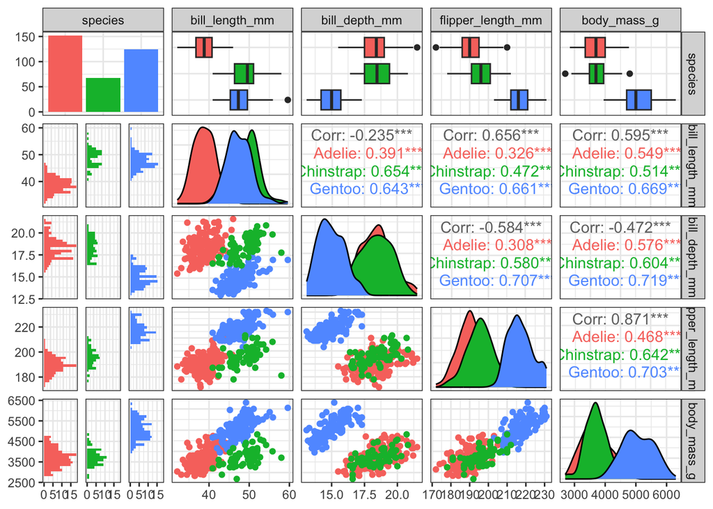

```r
require(GGally)
ggpairs(penguins[,c(1,3:6)], aes(color=species)) + theme_bw()
```

**Quiz yourself:** What variables do you think will be important in separating species based on the data exploration?

Next, it looks like we might have some collinearity issues. VIF measures start to have some trouble with these types of models - so one thing people have done is to create a basic lm model (yeah, wrong assumption of error distribution) to check for collinearity issues, then moving on to the right error distribution. Let’s try that.

```r
dummy.lm.vif <- lm(as.numeric(species) ~ bill_length_mm + bill_depth_mm + flipper_length_mm + body_mass_g, data = penguins)

vif(dummy.lm.vif)
```

```
##    bill_length_mm     bill_depth_mm flipper_length_mm       body_mass_g
##          1.868456          1.621511          5.930499          4.192353
```

Well, it does look like we might want to consider removing one of the variables of either flipper_length_mm or body_mass_g. Body mass is on a very different scale… so let’s try removing that one to see what happens.

```r
dummy.lm.vif2 <- lm(as.numeric(species) ~ bill_length_mm + bill_depth_mm + flipper_length_mm, data = penguins)

vif(dummy.lm.vif2)
```

```
##    bill_length_mm     bill_depth_mm flipper_length_mm
##          1.865090          1.611292          2.673338
```

Bummer. It is ok, but maybe I should try keeping body mass and removing flipper length.

```r
dummy.lm.vif3 <- lm(as.numeric(species) ~ bill_length_mm + bill_depth_mm + body_mass_g, data = penguins)

vif(dummy.lm.vif3)
```

```
## bill_length_mm  bill_depth_mm    body_mass_g
##       1.554855       1.291907       1.889820
```

```r
remove(dummy.lm.vif, dummy.lm.vif2, dummy.lm.vif3)
```

Yup, that one looks like the winner! Let’s move forward with these explanatory variables!

Hmm… also, it looks like all of our remaining explanatory variables are on very different scales, and we have some missing values - this might be a good opportunity to practice some standardizing methods!

```r
penguins.std <- penguins[complete.cases(penguins),c(1,3:4,6)]
penguins.std[,c(2:4)] <- scale(penguins.std[,c(2:4)])
colnames(penguins.std) <- c("species","bill_length_sd", "bill_depth_sd", "body_mass_sd")
```

### Describe the model

Let’s describe our full model mathematically…

#### Linear predictor

$$\eta_i = \beta_0 + \beta_1X_{1i} +
\beta_2X_{2i} + \beta_3X_{3i}$$

where:

- $\beta_0$ = the intercept where all explanatory variables are 0
- $\beta_1$ = is the slope of the relationship for $X_1$ or bill_length_sd
- $\beta_2$ = is the slope of the relationship for $X_2$ or bill_depth_sd
- $\beta_3$ = is the slope of the relationship for $X_3$ or body_mass_sd

#### Error distribution

$$e_{k,i} \sim Binomial(n, p_i)$$
The added *k* indicates that each probability of belonging to a group is also dependent on the linear combination of probabilities for the other groups.

#### Link

$$logit(\mu) = \eta$$

#### Fit the model/model selection

Let’s combine our fit the model and model selection phase by creating a model set list and using AIC to select the best model. To do a multinomial logistic regression, we will use the *multinom()* function from the *nnet* package.

```r
require(nnet)
require(AICcmodavg)

fitList <- list(
  "m.full" = multinom(species ~ bill_length_sd + bill_depth_sd  + body_mass_sd, data = penguins.std),
  "m.blbd" = multinom(species ~ bill_length_sd + bill_depth_sd, data = penguins.std),
  "m.blbm" = multinom(species ~ bill_length_sd  + body_mass_sd, data = penguins.std),
  "m.bdbm" = multinom(species ~ bill_depth_sd  + body_mass_sd, data = penguins.std),
  "m.bl" = multinom(species ~   bill_length_sd, data = penguins.std),
  "m.bd" = multinom(species ~ bill_depth_sd, data = penguins.std),
  "m.bm" = multinom(species ~ body_mass_sd, data = penguins.std),
  "m.0" = multinom(species ~ 1, data = penguins.std)
)

aictab(fitList)
```

[output not shown]

**Quiz yourself:** Which model would you choose?

#### Interpretation

Let’t take a look at the summary tables to see what they mean.

```r
m.full <- multinom(species ~ bill_length_sd + bill_depth_sd  + body_mass_sd, data = penguins.std)
summary(m.full)
```

[output not shown]

All right! Interesting - these summary tables look a little different! Let’s focus first just on the coefficient tables:

```r
summary(m.full)$coefficients
```

```
##           (Intercept) bill_length_sd bill_depth_sd body_mass_sd
## Chinstrap   2.0857912      103.93462     -47.96054    -47.14756
## Gentoo     -0.9046964       49.84946     -86.28014     24.05672
```

Awesome. So unlike in previous binomial logistic regression GLMs, we actually have TWO sets of equations here! The first equation/line labelled “Chinstrap” is actually the equation describing the log odds of being a Chinstrap penguin over an Adélie penguin given the explanatory variables with each estimate (under the name of the explanatory variable) showing the relationship between that explanatory variablel and the log odds. The second line, labelled “Gentoo” is the same, but the log odds of being a Gentoo penguin verses an Adélie penguin.

We can set these up to make them look a little more like the tables we are used to:

```r
t.chinstrap <- data.frame(summary(m.full)$coefficients[1,],summary(m.full)$standard.errors[1,])
colnames(t.chinstrap) <- c("estimate", "sd")
t.chinstrap
```

|  | estimate | sd |
| --- | --- | --- |
| (Intercept) | 2.085791 | 15.81933 |
| bill_length_sd | 103.934623 | 86.97010 |
| bill_depth_sd | -47.960543 | 41.16448 |
| body_mass_sd | -47.147557 | 45.14463 |

```r
t.gentoo <- data.frame(summary(m.full)$coefficients[2,],summary(m.full)$standard.errors[2,])
colnames(t.gentoo) <- c("estimate", "sd")
t.gentoo
```

|  | estimate | sd |
| --- | --- | --- |
| (Intercept) | -0.9046964 | 334.9131 |
| bill_length_sd | 49.8494617 | 1613.4071 |
| bill_depth_sd | -86.2801395 | 1176.7947 |
| body_mass_sd | 24.0567172 | 1969.5697 |

```r
remove(t.chinstrap, t.gentoo)
```

But remember that these are still on the linear predictor scale.

Let’s see what these relationships look like graphically and on our response scale.

First, let’s predict using our new model.

```r
# first let's make a new data frame with all possible combinations of explanatory variables
df.predict <- expand.grid(
  bill_length_sd = seq(min(penguins.std$bill_length_sd), max(penguins.std$bill_length_sd), length=20),
  bill_depth_sd = seq(min(penguins.std$bill_depth_sd), max(penguins.std$bill_depth_sd), length=20),
  body_mass_sd = seq(min(penguins.std$body_mass_sd), max(penguins.std$body_mass_sd), length=20)
)

# make predictions of the probability of falling into each species group by physical characteristics
df.pred2 <- cbind(df.predict, predict(m.full, newdata = df.predict, type = "probs", se = TRUE))
head(df.pred2)
```

|  | bill_length_sd | bill_depth_sd | body_mass_sd | Adelie | Chinstrap | Gentoo |
| --- | --- | --- | --- | --- | --- | --- |
| 1 | -2.1747146 | -2.064184 | -1.871619 | 0.00000000004798876702219907799196306642001638460143 | 0.000000000000000000000000005523707 | 1.0000000000 |
| 2 | -1.9100490 | -2.064184 | -1.871619 | 0.00000000000000008939274455717892900580600050540316 | 0.000000000000000000009097689485223 | 1.0000000000 |
| 3 | -1.6453834 | -2.064184 | -1.871619 | 0.00000000000000000000016651944350611545812721255479 | 0.000000000000014984132656874328282 | 1.0000000000 |
| 4 | -1.3807178 | -2.064184 | -1.871619 | 0.00000000000000000000000000031018987635542285941398 | 0.000000024679257992088343369198853 | 0.9999999753 |
| 5 | -1.1160522 | -2.064184 | -1.871619 | 0.00000000000000000000000000000000055524762911238553 | 0.039059709692517013968071637464163 | 0.9609402903 |
| 6 | -0.8513866 | -2.064184 | -1.871619 | 0.00000000000000000000000000000000000000000001607731 | 0.999985063102348359365123542374931 | 0.0000149369 |

```r
remove(df.predict)
```

Next let’s make a pretty plot! Notice our probabilities are dependent on 3 explanatory variables… that’s nearly impossible to plot! So, let’s make some smaller data frames for plotting. Let’s use bill length as our first explanatory value to plot.

```r
# Relationships with bill length
df.predict.bl <- expand.grid(
  bill_length_sd = seq(min(penguins.std$bill_length_sd), max(penguins.std$bill_length_sd), length=100),
  bill_depth_sd = mean(penguins.std$bill_depth_sd),
  body_mass_sd = mean(penguins.std$body_mass_sd)
)
df.pred.bl <- cbind(df.predict.bl, predict(m.full, newdata = df.predict.bl, type = "probs", se = TRUE))
head(df.pred.bl)
```

|  | bill_length_sd | bill_depth_sd | body_mass_sd | Adelie | Chinstrap | Gentoo |
| --- | --- | --- | --- | --- | --- | --- |
| 1 | -2.174715 | -0.000000000000001020872 | -0.0000000000000001366941 | 1 | 0.00000000000000000000000000000000000000000000000000000000000000000000000000000000000000000000000005534442 | 0.000000000000000000000000000000000000000000000003356963 |
| 2 | -2.123920 | -0.000000000000001020872 | -0.0000000000000001366941 | 1 | 0.00000000000000000000000000000000000000000000000000000000000000000000000000000000000000000000001086034701 | 0.000000000000000000000000000000000000000000000042229146 |
| 3 | -2.073126 | -0.000000000000001020872 | -0.0000000000000001366941 | 1 | 0.00000000000000000000000000000000000000000000000000000000000000000000000000000000000000000000213114788178 | 0.000000000000000000000000000000000000000000000531224438 |
| 4 | -2.022331 | -0.000000000000001020872 | -0.0000000000000001366941 | 1 | 0.00000000000000000000000000000000000000000000000000000000000000000000000000000000000000000041819946354546 | 0.000000000000000000000000000000000000000000006682574268 |
| 5 | -1.971537 | -0.000000000000001020872 | -0.0000000000000001366941 | 1 | 0.00000000000000000000000000000000000000000000000000000000000000000000000000000000000000008206412741453352 | 0.000000000000000000000000000000000000000000084063901539 |
| 6 | -1.920743 | -0.000000000000001020872 | -0.0000000000000001366941 | 1 | 0.00000000000000000000000000000000000000000000000000000000000000000000000000000000000001610360986887474446 | 0.000000000000000000000000000000000000000001057487617589 |

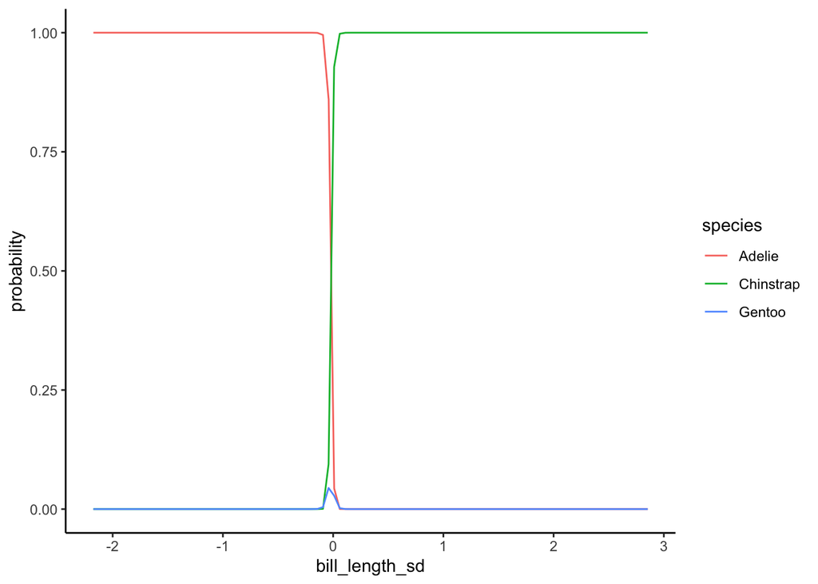

```r
remove(df.predict.bl)

## melt data set to long for plotting
df.bl.l <- gather(df.pred.bl, "species", "probability", 4:6)

# plot!
ggplot(df.bl.l, aes(x = bill_length_sd, y = probability, colour = species)) + geom_line() + theme_classic()
```

Interesting!! We are still using our standardized values for bill length - let’s see if we can make these a little more realistic!

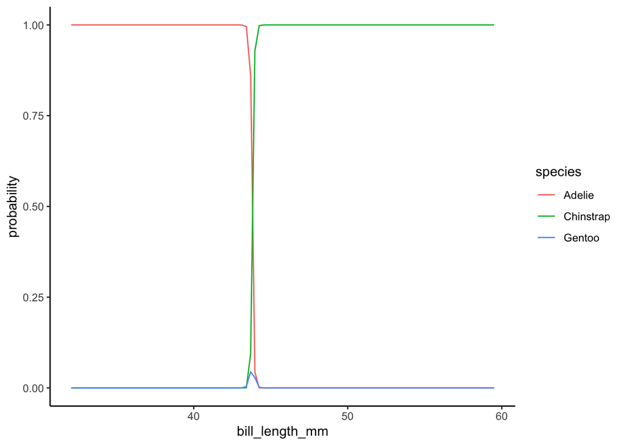

```r
df.bl.l$bill_length_mm <- (df.bl.l$bill_length_sd*sd(penguins$bill_length_mm,na.rm = TRUE))+mean(penguins$bill_length_mm,na.rm = TRUE)
df.bl.l$bill_depth_mm <- (df.bl.l$bill_depth_sd*sd(penguins$bill_depth_mm,na.rm = TRUE))+mean(penguins$bill_depth_mm,na.rm = TRUE)
df.bl.l$body_mass_g <- (df.bl.l$body_mass_sd*sd(penguins$body_mass_g,na.rm = TRUE))+mean(penguins$body_mass_g,na.rm = TRUE)

# plot!
ggplot(df.bl.l, aes(x = bill_length_mm, y = probability, colour = species)) + geom_line() + theme_classic()
```

Better! At least we seem to be looking at things in realistic measurement values.

Let’s do this for the other two explanatory variables!

```r
df.predict.bd <- expand.grid(
  bill_length_sd = mean(penguins.std$bill_length_sd),
  bill_depth_sd = seq(min(penguins.std$bill_depth_sd), max(penguins.std$bill_depth_sd), length=100),
  body_mass_sd = mean(penguins.std$body_mass_sd)
)
df.pred.bd <- cbind(df.predict.bd, predict(m.full, newdata = df.predict.bd, type = "probs", se = TRUE))
head(df.pred.bd)
```

|  | bill_length_sd | bill_depth_sd | body_mass_sd | Adelie | Chinstrap | Gentoo |
| --- | --- | --- | --- | --- | --- | --- |
| 1 | -0.000000000000003752754 | -2.064184 | -0.0000000000000001366941 | 0.00000000000000000000000000000000000000000000000000000000000000000000000000001111424 | 0.0000000000000000000000000000000008843406 | 1 |
| 2 | -0.000000000000003752754 | -2.021097 | -0.0000000000000001366941 | 0.00000000000000000000000000000000000000000000000000000000000000000000000000045750183 | 0.0000000000000000000000000000000046097065 | 1 |
| 3 | -0.000000000000003752754 | -1.978010 | -0.0000000000000001366941 | 0.00000000000000000000000000000000000000000000000000000000000000000000000001883241463 | 0.0000000000000000000000000000000240285175 | 1 |
| 4 | -0.000000000000003752754 | -1.934923 | -0.0000000000000001366941 | 0.00000000000000000000000000000000000000000000000000000000000000000000000077520967174 | 0.0000000000000000000000000000001252508498 | 1 |
| 5 | -0.000000000000003752754 | -1.891836 | -0.0000000000000001366941 | 0.00000000000000000000000000000000000000000000000000000000000000000000003191040803154 | 0.0000000000000000000000000000006528815344 | 1 |
| 6 | -0.000000000000003752754 | -1.848749 | -0.0000000000000001366941 | 0.00000000000000000000000000000000000000000000000000000000000000000000131354674465369 | 0.0000000000000000000000000000034032048382 | 1 |

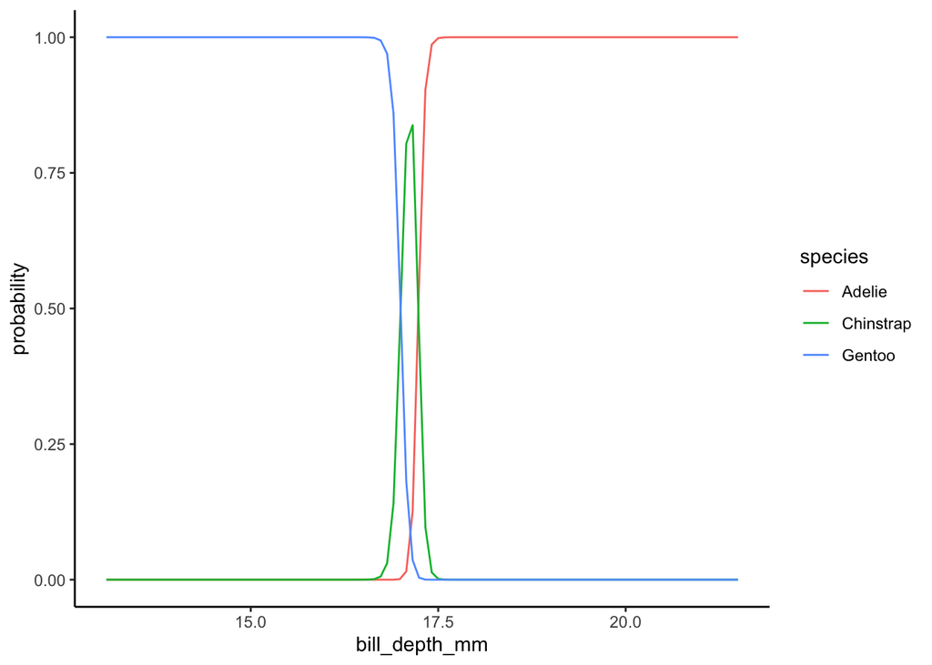

```r
remove(df.predict.bd)

## melt data set to long for plotting
df.bd.l <- gather(df.pred.bd, "species", "probability", 4:6)

df.bd.l$bill_length_mm <- (df.bd.l$bill_length_sd*sd(penguins$bill_length_mm,na.rm = TRUE))+mean(penguins$bill_length_mm,na.rm = TRUE)
df.bd.l$bill_depth_mm <- (df.bd.l$bill_depth_sd*sd(penguins$bill_depth_mm,na.rm = TRUE))+mean(penguins$bill_depth_mm,na.rm = TRUE)
df.bd.l$body_mass_g <- (df.bd.l$body_mass_sd*sd(penguins$body_mass_g,na.rm = TRUE))+mean(penguins$body_mass_g,na.rm = TRUE)

# plot!
ggplot(df.bd.l, aes(x = bill_depth_mm, y = probability, colour = species)) + geom_line() + theme_classic()
```

```r
df.predict.bm <- expand.grid(
  bill_length_sd = mean(penguins.std$bill_length_sd),
  bill_depth_sd = mean(penguins.std$bill_depth_sd),
  body_mass_sd = seq(min(penguins.std$body_mass_sd), max(penguins.std$body_mass_sd), length=100)
)
df.pred.bm <- cbind(df.predict.bm, predict(m.full, newdata = df.predict.bm, type = "probs", se = TRUE))
head(df.pred.bm)
```

|  | bill_length_sd | bill_depth_sd | body_mass_sd | Adelie | Chinstrap | Gentoo |
| --- | --- | --- | --- | --- | --- | --- |
| 1 | -0.000000000000003752754 | -0.000000000000001020872 | -1.871619 | 0.0000000000000000000000000000000000000005902385 | 1 | 0.000000000000000000000000000000000000000000000000000000000006668248 |
| 2 | -0.000000000000003752754 | -0.000000000000001020872 | -1.826459 | 0.0000000000000000000000000000000000000049627519 | 1 | 0.000000000000000000000000000000000000000000000000000000000166159833 |
| 3 | -0.000000000000003752754 | -0.000000000000001020872 | -1.781299 | 0.0000000000000000000000000000000000000417270416 | 1 | 0.000000000000000000000000000000000000000000000000000000004140381590 |
| 4 | -0.000000000000003752754 | -0.000000000000001020872 | -1.736138 | 0.0000000000000000000000000000000000003508428494 | 1 | 0.000000000000000000000000000000000000000000000000000000103170299440 |
| 5 | -0.000000000000003752754 | -0.000000000000001020872 | -1.690978 | 0.0000000000000000000000000000000000029499025146 | 1 | 0.000000000000000000000000000000000000000000000000000002570804273791 |
| 6 | -0.000000000000003752754 | -0.000000000000001020872 | -1.645818 | 0.0000000000000000000000000000000000248029135019 | 1 | 0.000000000000000000000000000000000000000000000000000064059469149596 |

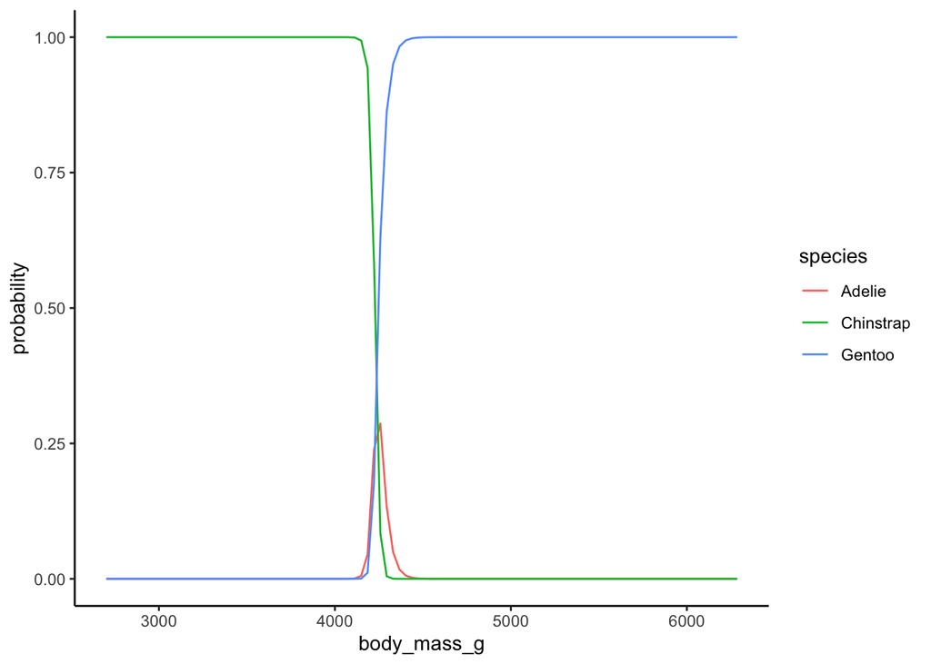

```r
remove(df.predict.bm)

## melt data set to long for plotting
df.bm.l <- gather(df.pred.bm, "species", "probability", 4:6)

df.bm.l$bill_length_mm <- (df.bm.l$bill_length_sd*sd(penguins$bill_length_mm,na.rm = TRUE))+mean(penguins$bill_length_mm,na.rm = TRUE)
df.bm.l$bill_depth_mm <- (df.bm.l$bill_depth_sd*sd(penguins$bill_depth_mm,na.rm = TRUE))+mean(penguins$bill_depth_mm,na.rm = TRUE)
df.bm.l$body_mass_g <- (df.bm.l$body_mass_sd*sd(penguins$body_mass_g,na.rm = TRUE))+mean(penguins$body_mass_g,na.rm = TRUE)

# plot!
ggplot(df.bm.l, aes(x = body_mass_g, y = probability, colour = species)) + geom_line() + theme_classic()
```

**Quiz yourself:** What do you learn from these plots?